# Partisanship and Competitive Elections: Notebook 5

Keith Colella

2023-05-14

```r
library(tidyverse)
library(kableExtra)
library(tigris)
library(sf)
```

## District-Level Ideology Survey

This notebook collects a number of measures of district competitiveness / ideological leanings and maps them to the candidates dataframe from previous notebooks. The output of this notebook will serve as the final dataset for this project’s ultimate statistical analysis.

## Survey-Based District-Level Ideology Scores

The first measure comes from a 2022 study gathering more than a decade of survey data to model ideology at the district level (https://dataverse.harvard.edu/dataset.xhtml?persistentId=doi:10.7910/DVN/BQKU4M). As with many of the partisanship scores, the scale is oriented such that “lower values are associated with politically left preferences and higher values with politically right preferences.” So, I will normalize the scores between -1 and 1, then take the absolute value. The results scores will then be oriented such that 0 indicates closeness to the political center and 1 indicates closeness to ideological wings, matching the orientation of the partisanship scores from notebook 4.

```r
load('data/aip_district_ideology_v2022a.RData')
district_ideology <- table
rm(table)

district_ideology %>% head()
```

```
## # A tibble: 6 × 14
##   cd_fips state    mrp_ideology_se mrp_ideology irt_ideology_unweighted
##   <chr>   <chr>              <dbl>        <dbl>                   <dbl>
## 1 1000    Delaware          0.0696      -0.0459                 -0.0182
## 2 1000    Delaware          0.0429      -0.0213                 -0.0651
## 3 1000    Delaware          0.0409      -0.0710                 -0.0798
## 4 1000    Delaware          0.0409      -0.0710                 -0.0735
## 5 1000    Delaware          0.0409      -0.0710                 -0.0763
## 6 101     Alabama           0.0687       0.201                   0.185
## # ℹ 9 more variables: self_ideology <dbl>, self_ideology_se <dbl>,
## #   irt_ideology_unweighted_sd <dbl>, irt_ideology_unweighted_se <dbl>,
## #   sample_size <dbl>, demshare_pres <dbl>, presidential_year <dbl>,
## #   congress <dbl>, survey_period <chr>
```

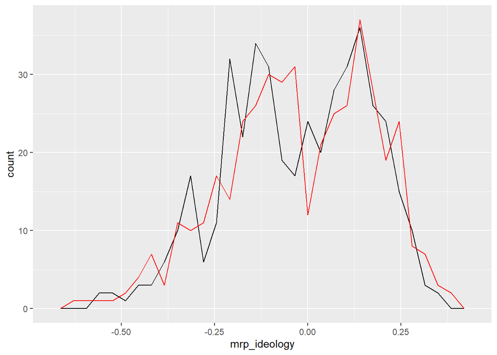

```r
district_ideology %>%
  filter(congress == 118) %>%
  ggplot() +
  geom_freqpoly(aes(mrp_ideology)) +
  geom_freqpoly(aes(irt_ideology_unweighted), color = 'red')
```

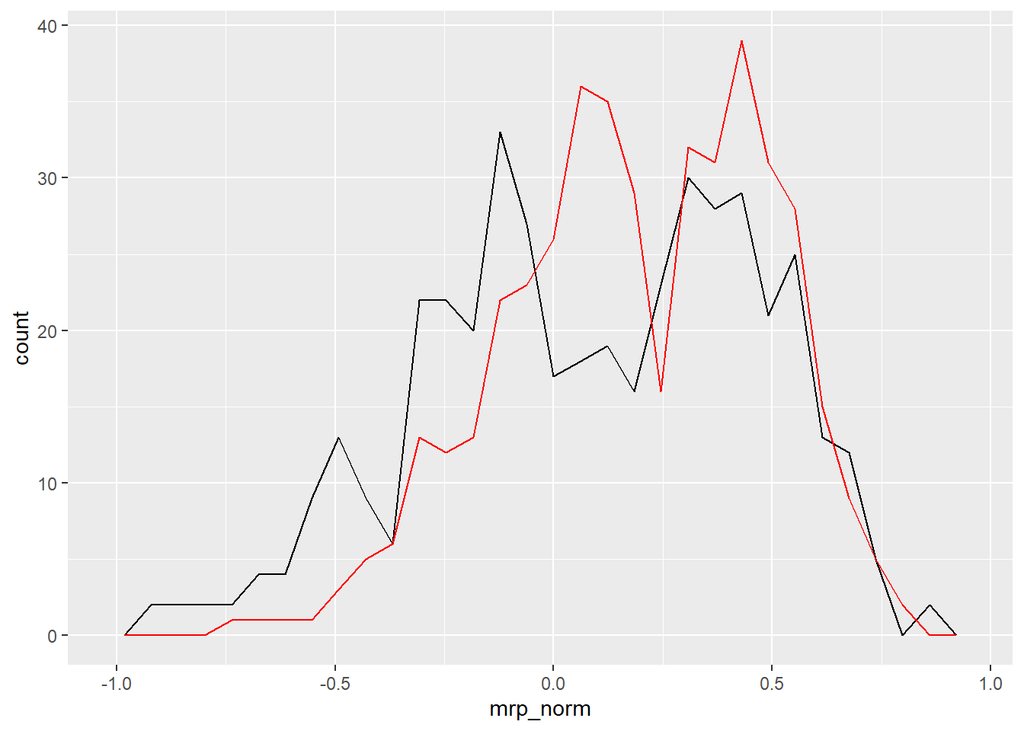

```r
min_score <- min(district_ideology$mrp_ideology, na.rm = TRUE)
max_score <- max(district_ideology$mrp_ideology, na.rm = TRUE)

district_ideology <- district_ideology %>%
  mutate(mrp_norm = 2 * (mrp_ideology - min_score) / (max_score - min_score) - 1,
         mrp_norm_abs = abs(mrp_norm))

min_score <- min(district_ideology$irt_ideology_unweighted, na.rm = TRUE)
max_score <- max(district_ideology$irt_ideology_unweighted, na.rm = TRUE)

district_ideology <- district_ideology %>%
  mutate(itr_norm = 2 * (irt_ideology_unweighted - min_score) / (max_score - min_score) - 1,
         itr_norm_abs = abs(itr_norm))

district_ideology %>%
  filter(congress == 118) %>%
  ggplot() +
  geom_freqpoly(aes(mrp_norm)) +
  geom_freqpoly(aes(itr_norm), color = 'red')
```

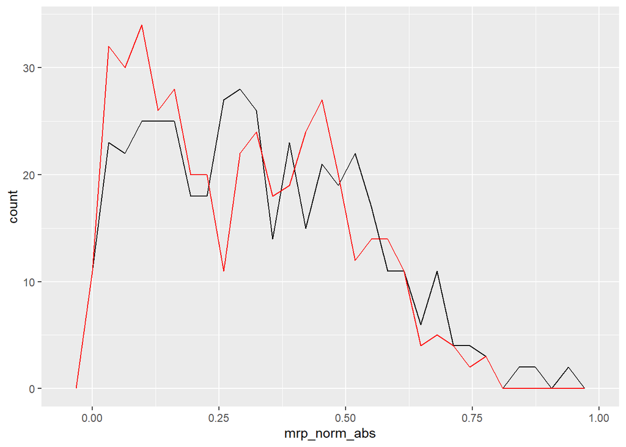

```r
district_ideology %>%
  filter(congress == 118) %>%
  ggplot() +
  geom_freqpoly(aes(mrp_norm_abs)) +
  geom_freqpoly(aes(itr_norm_abs), color = 'red')
```

## Cook Partisan Voting Index

The next measure is the Cook PVI (https://www.cookpolitical.com/cook-pvi/2022-partisan-voting-index/district-map-and-list). This measure uses historical voting results to assign each congressional district a score from far left to far right. As above, we’ll normalize the score between -1 and 1 and take the absolutely value

```r
cookpvi <- read_csv('data/cook_pvi.csv')
```

```
## ──────────────────────────────────────────────────────── Delimiter: "," chr
## (9): district, name, party, district_description, pvi, biden, trump...7,...
```

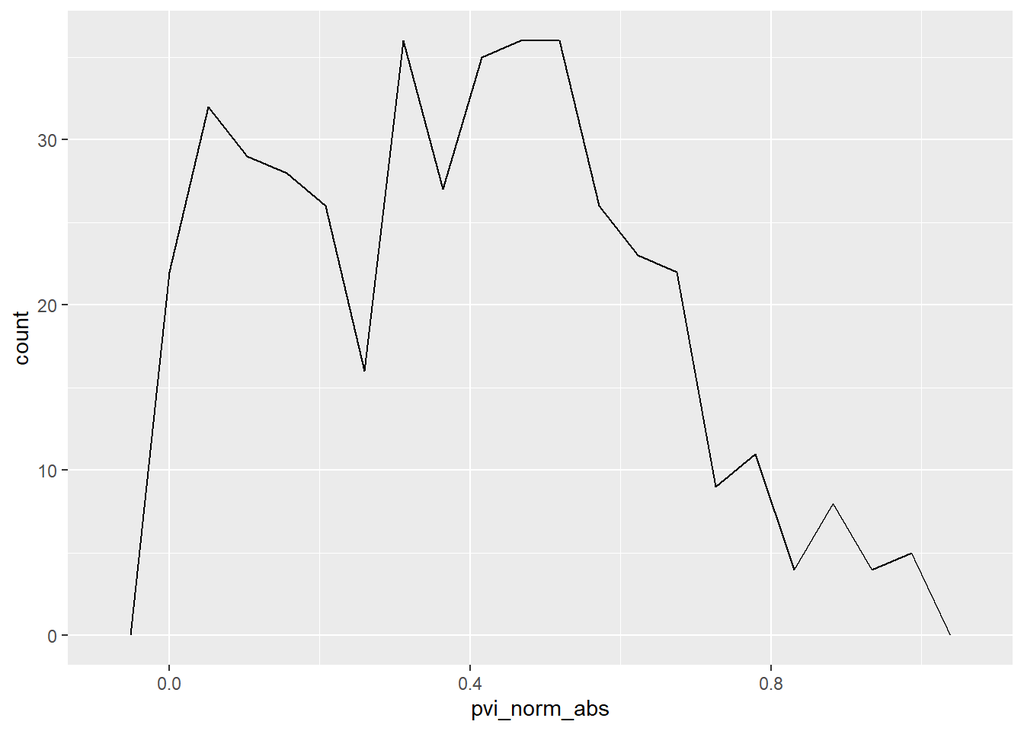

```r
cookpvi <- cookpvi %>%
  rename(trump2020 = trump...7,
         trump2016 = trump...9) %>%
  mutate(pvi_num =
           case_when(str_detect(pvi,'R') ~ as.numeric(str_extract(pvi,'[0-9]+')),
                     str_detect(pvi,'D') ~ as.numeric(str_extract(pvi,'[0-9]+'))*-1,
                     TRUE ~ 0))

min_score <- min(cookpvi$pvi_num)
max_score <- max(cookpvi$pvi_num)

cookpvi <- cookpvi %>%
  mutate(pvi_abs = abs(pvi_num),
         pvi_norm = 2 * (pvi_num - min_score) / (max_score - min_score) - 1,
         pvi_norm_abs = abs(pvi_norm))

cookpvi %>%
  ggplot() +
  geom_freqpoly(aes(pvi_norm_abs), bins = 20)
```

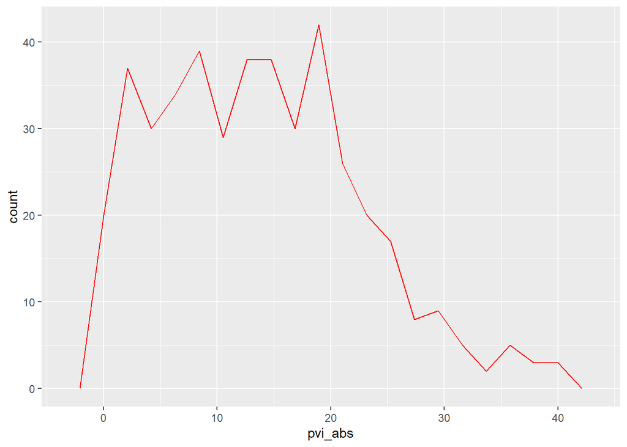

```r
cookpvi %>%
  ggplot() +
  geom_freqpoly(aes(pvi_abs), bins = 20, color = 'red')
```

## Efficiency Gap

The final measure is the Efficiency Gap. This metric is frequently cited in political science literature as a measure of gerrymandering (see Stephanopoulos, Nicholas, and McGhee. “Partisan Gerrymandering and the Efficiency Gap.”). The Efficiency Gap measures “wasted” votes, framed as the amount of (i) votes cast for a candidate who didn’t win, or (ii) votes cast for a candidate who did win *in excess* of the number of votes required to win.

I was unable to locate a readily available measure of the effiency gap, so I’ll calculate my own using historical election data from the MIT Election Lab (https://electionlab.mit.edu/data).

```r
elections <- read_csv('data/1976-2020-house.csv')
elections <- elections %>%
  filter(stage == 'GEN',
         year > 2010) %>%
  mutate(yearStateDist = paste0(year, state_po, district))

elections <- elections %>%
  group_by(yearStateDist) %>%
  mutate(result = case_when(candidatevotes == max(candidatevotes) ~ 'winner',
                            candidatevotes != max(candidatevotes) ~ 'loser')) %>%
  ungroup()

elections <- elections %>%
  mutate(wastedVotes = case_when(result == 'winner' ~ (candidatevotes - (totalvotes %/% 2)),
                                 result == 'loser' ~ candidatevotes),
         wastedVotes = case_when(party == 'DEMOCRAT' ~ -wastedVotes,
                                 party == 'REPUBLICAN' ~ wastedVotes,
                                 TRUE ~ 0))

eff_gap <- elections %>%
  group_by(year, state_po, district) %>%
  summarize(netWastedVotes = sum(wastedVotes),
            totalVotes = sum(totalvotes),
            eff_gap = abs(netWastedVotes / totalVotes),
            .groups = 'drop') %>%
  group_by(state_po, district) %>%
  summarize(avg_eff_gap = mean(eff_gap),
            .groups = 'keep') %>%
  ungroup()

summary(eff_gap)
```

```
##    state_po           district          avg_eff_gap
##  Length:436         Length:436         Min.   :0.005533
##  Class :character   Class :character   1st Qu.:0.059444
##  Mode  :character   Mode  :character   Median :0.094613
##                                        Mean   :0.101799
##                                        3rd Qu.:0.132682
##                                        Max.   :0.465411
##                                        NA's   :1
```

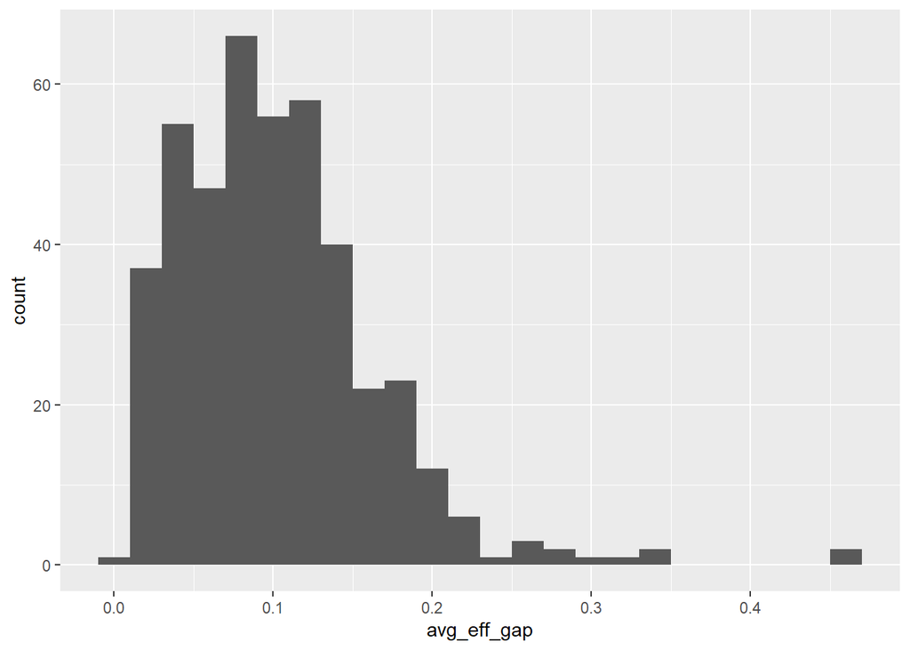

```r
eff_gap %>%
  ggplot(aes(avg_eff_gap)) +
  geom_histogram(binwidth = 0.02)
```

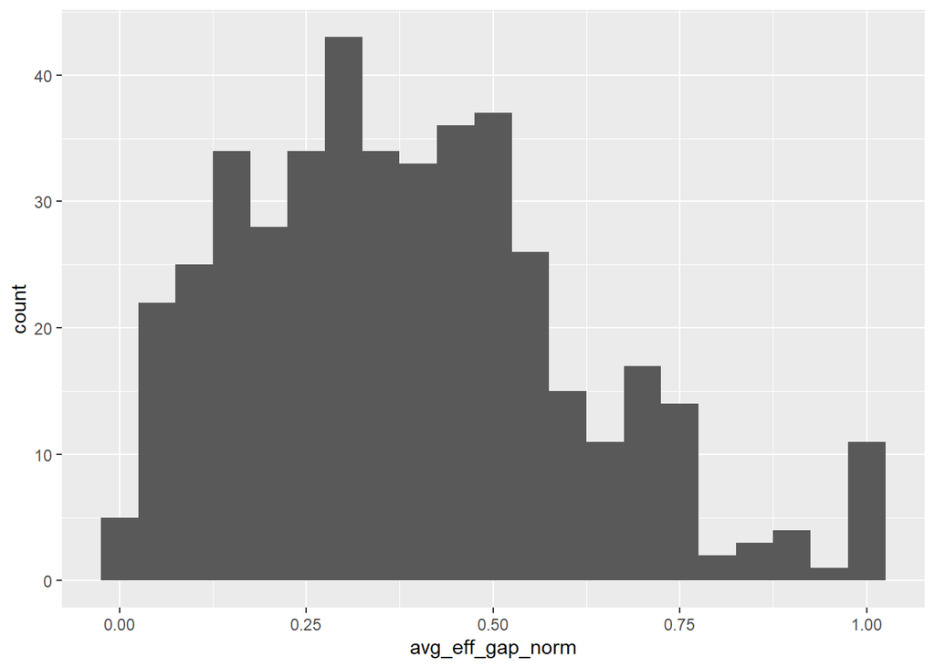

```r
eff_gap <- eff_gap %>%
  mutate(avg_eff_gap = if_else(avg_eff_gap > 0.25, 0.25, avg_eff_gap))

min_score <- min(eff_gap$avg_eff_gap, na.rm = TRUE)
max_score <- max(eff_gap$avg_eff_gap, na.rm = TRUE)

eff_gap <- eff_gap %>%
  mutate(avg_eff_gap_norm = (avg_eff_gap - min_score) / (max_score - min_score))

eff_gap %>%
  ggplot(aes(avg_eff_gap_norm)) +
  geom_histogram(binwidth = 0.05)
```

```r
eff_gap %>%
  arrange(desc(avg_eff_gap))
```

```
## # A tibble: 436 × 4
##    state_po district avg_eff_gap avg_eff_gap_norm
##    <chr>    <chr>          <dbl>            <dbl>
##  1 FL       010             0.25                1
##  2 FL       012             0.25                1
##  3 FL       014             0.25                1
##  4 FL       015             0.25                1
##  5 FL       021             0.25                1
##  6 FL       025             0.25                1
##  7 FL       027             0.25                1
##  8 GA       003             0.25                1
##  9 GA       005             0.25                1
## 10 OK       001             0.25                1
## # ℹ 426 more rows
```

## Unified Dataset

Finally, I’ll combine datasets together and map them to the candidates dataframe.

First, I need to account for states that have only a single congressional district, as the naming convention used to identify that district differs across datasets.

```r
one_dist_state_regex <- 'AK|WY|ND|SD|VT|DE|DC|MT'
```

Then, I’ll prepare the dataframes themselves, aligning the naming of states and districts.

```r
district_ideology <- district_ideology %>%
  filter(state != 'NA', !is.na(mrp_ideology), !is.na(irt_ideology_unweighted)) %>%
  mutate(cd_fips = sprintf('%04d', as.numeric(cd_fips)),
         state_code = str_sub(cd_fips, 1, 2),
         district = str_sub(cd_fips, 3, 4)) %>%
  left_join(
    data.frame(state = state.name,
               state_abb = state.abb)) %>%
  arrange(cd_fips, desc(congress)) %>%
  mutate(state_abb = if_else(is.na(state_abb), 'DC', state_abb),
         district = if_else(str_detect(state_abb,one_dist_state_regex),
                            '00',district),
         dupe = duplicated(cd_fips)) %>%
  filter(dupe == FALSE) %>%
  rename(compete_ideology = mrp_norm_abs)
cookpvi <- cookpvi %>%
  rename(state_dist = district) %>%
  mutate(state = str_sub(state_dist, 1, 2),
         district = str_sub(state_dist, 4, 5),
         district = if_else(str_detect(state, one_dist_state_regex),
                            '00', district)) %>%
  rename(compete_cookpvi = pvi_norm_abs)

eff_gap <- eff_gap %>%
  mutate(district = sprintf('%02d', as.numeric(district)),
         district = if_else(str_detect(state_po, one_dist_state_regex),
                            '00', district)) %>%
  rename(compete_eff_gap = avg_eff_gap_norm)
```

Finally, I’ll read in the candidates data and perform the join.

```r
candidates <- read_csv('data/candidates_partisanship.csv')
candidates <- candidates %>%
  mutate(district = sprintf('%02d', district),
         district = if_else(str_detect(state, one_dist_state_regex),
                            '00', district)) %>%
  left_join(
    select(district_ideology, compete_ideology, state_abb, district),
    by = c('state' = 'state_abb', 'district')
  ) %>%
  left_join(
    select(cookpvi, compete_cookpvi, state, district),
    by = c('state', 'district')
  ) %>%
  left_join(
    select(eff_gap, compete_eff_gap, state_po, district),
    by = c('state' = 'state_po', 'district')
  )
data('fips_codes')

districts_sf <- congressional_districts() %>%
  st_simplify(dTolerance = 10000) %>%
  data.frame() %>%
  left_join(
    fips_codes %>%
      select(state, state_code) %>%
      unique(),
    by = c('STATEFP' = 'state_code')
  )
states_sf <- states(cb = TRUE) %>%
  st_simplify(dTolerance = 1000) %>%
  data.frame() %>%
  filter(STUSPS != 'AS',
         STUSPS != 'GU',
         STUSPS != 'MP',
         STUSPS != 'VI',
         STUSPS != 'PR',)
candidates_sf <- candidates %>%
  left_join(
    select(districts_sf, state, CD116FP, geometry),
    by = c('state', 'district' = 'CD116FP'),
  ) %>%
  left_join(
    select(states_sf, STUSPS, geometry), suffix = c('_distr','_state'),
    by = c('state' = 'STUSPS')
  )
```

I’ll also put together a few geographic visuals, mapping scores onto a map. I’ll use the `tigris` package (https://cran.r-project.org/web/packages/tigris/tigris.pdf).

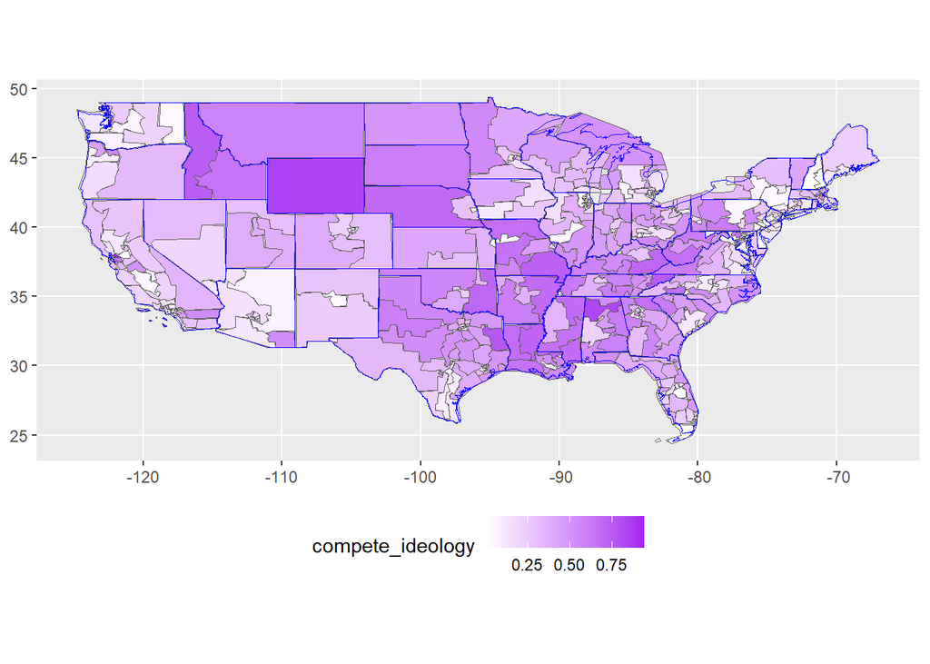

```r
candidates_sf %>%
  filter(state != 'HI',
         state != 'AK',
         state != 'PR') %>%
  ggplot() +
  geom_sf(aes(geometry = geometry_distr, fill = compete_ideology)) +
  geom_sf(aes(geometry = geometry_state), color = 'blue', size = 0.5, fill = NA) +
  scale_fill_gradient(low = 'gray100',
                      high = 'purple') +
  theme(legend.position="bottom")
```

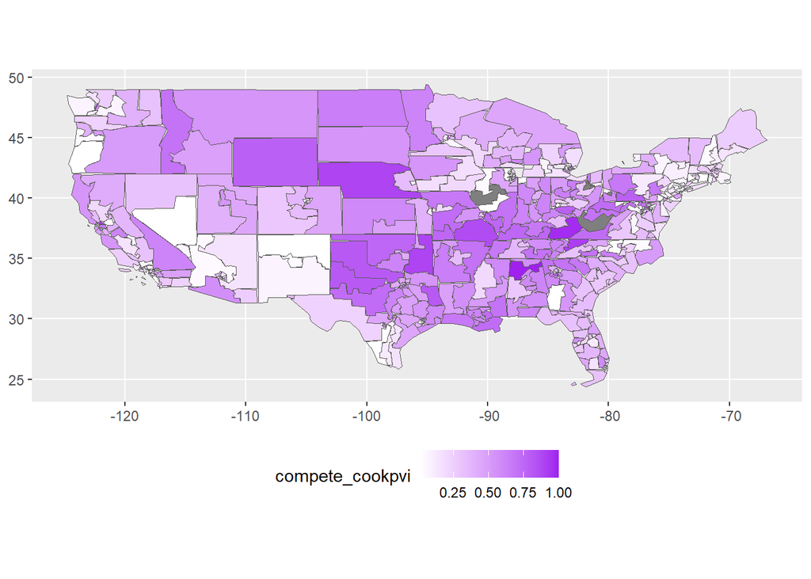

```r
candidates_sf %>%
  filter(state != 'HI',
         state != 'AK',
         state != 'PR') %>%
  ggplot() +
  geom_sf(aes(geometry = geometry_distr, fill = compete_cookpvi)) +
  scale_fill_gradient(low = 'gray100',
                      high = 'purple') +
  theme(legend.position="bottom")
```

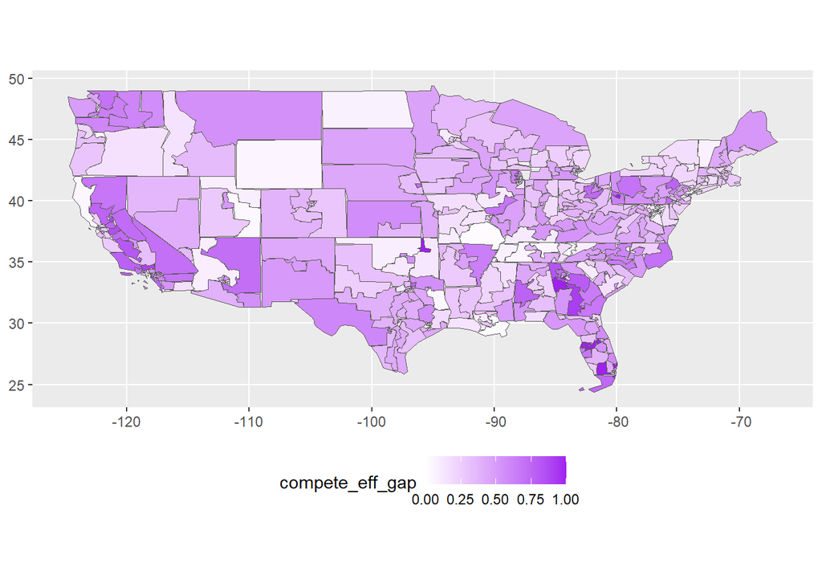

```r
candidates_sf %>%
  filter(state != 'HI',
         state != 'AK',
         state != 'PR') %>%
  ggplot() +
  geom_sf(aes(geometry = geometry_distr, fill = compete_eff_gap)) +
  scale_fill_gradient(low = 'gray100',
                      high = 'purple') +
  theme(legend.position="bottom")
```

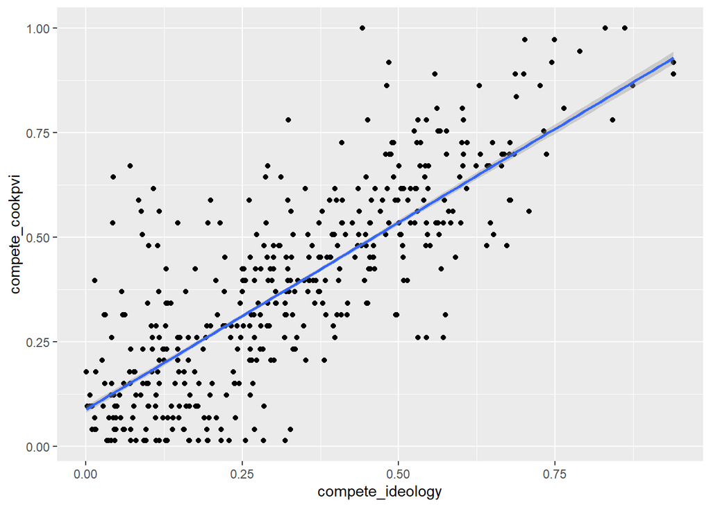

```r
candidates %>%
  ggplot(aes(compete_ideology, compete_cookpvi)) +
  geom_point() +
  geom_smooth(method = 'lm', formula = 'y ~ x')
```

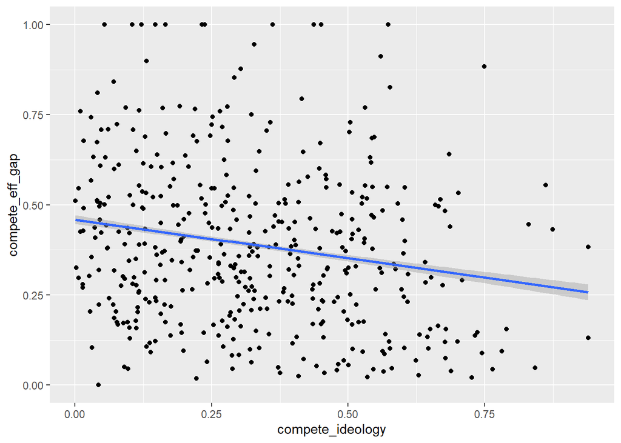

```r
candidates %>%
  ggplot(aes(compete_ideology, compete_eff_gap)) +
  geom_point() +
  geom_smooth(method = 'lm', formula = 'y ~ x')
```

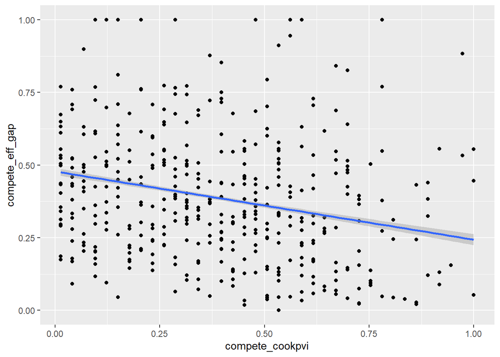

```r
candidates %>%
  ggplot(aes(compete_cookpvi, compete_eff_gap)) +
  geom_point() +
  geom_smooth(method = 'lm', formula = 'y ~ x')
```

Distributions

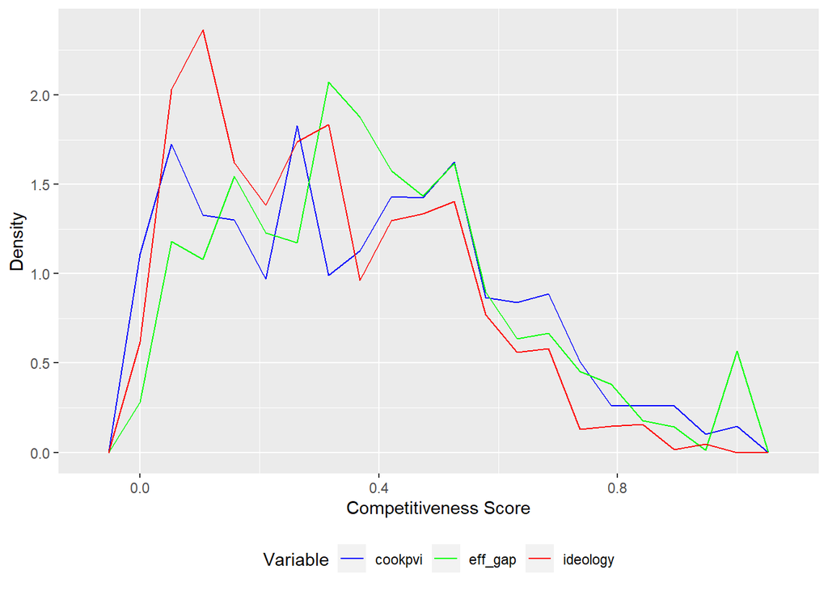

```r
candidates %>%
  mutate(dupe = duplicated(name)) %>%
  filter(dupe == FALSE) %>%
  ggplot() +
  geom_freqpoly(aes(compete_cookpvi, after_stat(density), color = 'blue'), bins = 20) +
  geom_freqpoly(aes(compete_eff_gap, after_stat(density), color = 'green'), bins = 20) +
  geom_freqpoly(aes(compete_ideology, after_stat(density), color = 'red'), bins = 20) +
  scale_colour_manual(name = 'Variable',
                      values = c('blue' = 'blue', 'green' = 'green', 'red' = 'red'),
                      labels = c('cookpvi','eff_gap', 'ideology')) +
  xlab('Competitiveness Score') +
  ylab('Density') +
  theme(legend.position = 'bottom')
```

Export

```r
write_csv(candidates, 'data/candidates_partisan_compete.csv')
```